# Trabajo Final

Alessa Garcia- Omar Triveño

17/12/2021

```r
library(rmdformats)
```

Repositorio github:

https://github.com/Alessth/TrabajoFinal

```r
knitr::opts_chunk$set(echo = TRUE)
```

```r
library(rio)
```

```r
setwd("C:/Users/USER/Desktop/clases/sociales/CICLO II/ESTADISTICA II/trab")
data=import("Base.sav")
```

Introducción:

En el año 2014 se dio la Reforma Universitaria la cual fue una respuesta del gobierno de turno a la exigencia ciudadana por incrementar la calidad en la educación superior. En consecuencia, desde su formulación hasta la fecha en la cual se está escribiendo esta investigación, la SUNEDU, ente regulador creado con el propósito de cumplir con los propósitos planteados en la Reforma Universitaria, ha cerrado 13 universidades ilegales y sancionado 32 universidades por programas y establecimientos no autorizados. Sin embargo, a pesar que su labor ha sido reconocida por la mejora en la calidad, ha recibido diversos intentos de grupos con intereses particulares y representación en el Congreso de la República que han colocado impedimentos para su implementación.

En este sentido, la investigación se propone identificar aquellos factores asociados que estén relacionados con la calidad en la formación profesional que los estudiantes reciben en las universidades y su perspectiva respecto al desarrollo del centro de estudios. Dado que la Reforma Universitaria del año 2014 se ha centrado en el establecimiento de estándares mínimos y óptimos para el licenciamiento de las universidades, vemos que estos dos elementos se encuentran también en el II CENAUN 2010. Este fue un censo a nivel nacional llevado a cabo por el INEI bajo el método del autoempadronamiento donde los estudiantes registran sus respuestas a través de internet y acceso a cédulas electrónicas.

En adición, la población partícipe es toda la comunidad universitaria del Perú, agrupadas en las 35 universidades públicas y 65 universidades privadas del país. Además, la encuesta se encuentra regulada a través de tres resoluciones: la Resolución 1137-2009- ANR en la cual se aprueba el Marco de Cooperación Interinstitucional entre la Asamblea Nacional de Rectores y el INEI para el ejecución del II CENAUN 2010; la Resolución 1404-2009-ANR por la cual se dispone la participación en el II CENAUN 2010 de las universidades que conforman el Sistema Universitario, así como financiar y asumir el gasto de la realización del referido censo; y la Resolución 007-2010-INEI, por la cual se establece que el INEI realizará el planeamiento, programación, control y supervisión del II CENAUN 2010.

Por lo tanto, la investigación en base a los datos del II CENAUN 2010 tiene como pregunta de investigación: “¿Qué factores influyen en la relación de la aprobación otorgada por los estudiantes respecto a los servicios y áreas universitarias en la calidad formativa y desarrollo de las universidades?”. En este sentido, la hipótesis de la investigación viene a ser: la aprobación respecto a la aprobación en áreas universitarias contribuye más en la calidad formativa y desarrollo de las universidades, a comparación de la los servicios universitarios.

Metodología: La base de datos proviene de la página web del INEI, esta base tiene 9 capítulos, para este trabajo emplearemos todas las variables del capítulo 8, enfocadas a los estudiantes universitarios de pregrado.La encuesta fue realizada de forma voluntaria mediante internet por los mismos .De la base de datos empleamos todas las variables del capítulo 8, enfocadas a los estudiantes universitarios de pregrado. La cobertura geografica es el Perú, el método es el autoempadronamiento de los mediante internet por cédulas electrónicas.Nuestra unidad de muestreo son los estudiantes de pregrado del capitulo 8. Nuestro metodo de analisis es el analisis factorial por factor común.

Bibligrafía:

Ley universitaria (2014, julio). Perú: Minedu. Disponible en: http://www.minedu.gob.pe/reforma-universitaria/pdf/ley_universitaria.pdf

Resolución 1137 de 2009 [Ministerio de Educación]. Por la cual se aprueba el Marco de Cooperación Interinstitucional entre la Asamblea Nacional de Rectores y el Instituto Nacional de Estadística e Informática para la ejecución del II CENAUN 2010. 1 de enero de 2010.

Resolución 1404 de 2009 [Ministerio de Educación]. Por la cual se dispone la participación en el II CENAUN 2010 de las universidades que conforman el Sistema Nacional Universitario. 1 de enero de 2010.

Resolución Jefatural 007 de 2010 [Ministerio de Educación]. Por la cual se establece que el INEI realizará el planeamiento, programación, control y supervisión del II CENAUN 2010. 1 de enero de 2010.

SUNEDU. (9 de julio de 2020). 6 años de Reforma Universitaria.6 años de Reforma Universitaria (sunedu.gob.pe)

Análisis de datos: Convertimos a numericas las variables

```r
library(Rmisc)
library(dplyr)
```

```r
data1=select(data,CALIDAD_UNIV,PERSPECTIVA,CALI_SERVICIOS_1,CALI_SERVICIOS_2,CALI_SERVICIOS_3,CALI_SERVICIOS_4,CALI_SERVICIOS_5,CALI_SERVICIOS_6,CALI_SERVICIOS_7,CALI_SERVICIOS_8,CALI_SERVICIOS_9,CALI_SERVICIOS_10,CALI_SERVICIOS_11,CALI_AREAS_1,CALI_AREAS_2,CALI_AREAS_3,CALI_AREAS_4,CALI_AREAS_5,CALI_AREAS_6,CALI_AREAS_7,CALI_AREAS_8,CALI_AREAS_9,CALI_AREAS_10,CURSO,INVES,ORG_ESTU,ACT_CULTURAL,PRAC_DEPO,USO_BIBLIOTRADI,USO_BIBLIOVIRTUAL,BECA_UNIV)
str(data1)
```

```
## 'data.frame':    782970 obs. of  31 variables:
##  $ CALIDAD_UNIV     : chr  "" "" "" "2" ...
##   ..- attr(*, "label")= chr "CÓMO PERCIBE LA CALIDAD DE LA FORMACIÓN PROFESIONAL QUE RECIBE EN SU UNIVERSIDAD"
##   ..- attr(*, "format.spss")= chr "A1"
##   ..- attr(*, "display_width")= int 1
##   ..- attr(*, "labels")= Named chr [1:4] "1" "2" "3" "4"
##   .. ..- attr(*, "names")= chr [1:4] "EXCELENTE" "BUENA" "REGULAR" "MALA"
##  $ PERSPECTIVA      : chr  "1" "2" "2" "2" ...
##   ..- attr(*, "label")= chr "PERSPECTIVA RESPECTO AL DESARROLLO DE SU UNIVERSIDAD"
##   ..- attr(*, "format.spss")= chr "A1"
##   ..- attr(*, "display_width")= int 1
##   ..- attr(*, "labels")= Named chr [1:4] "1" "2" "3" "4"
##   .. ..- attr(*, "names")= chr [1:4] "Excelente" "Buena" "Regular" "Mala"
##  $ CALI_SERVICIOS_1 : chr  "1" "5" "5" "2" ...
##   ..- attr(*, "label")= chr "CÓMO CALIFICARÍA LOS SERVICIOS MÉDICOS QUE BRINDA SU UNIVERSIDAD"
##   ..- attr(*, "format.spss")= chr "A1"
##   ..- attr(*, "display_width")= int 1
##   ..- attr(*, "labels")= Named chr [1:6] "1" "2" "3" "4" ...
##   .. ..- attr(*, "names")= chr [1:6] "Excelente" "Bueno" "Regular" "Malo" ...
##  $ CALI_SERVICIOS_2 : chr  "5" "5" "5" "2" ...
##   ..- attr(*, "label")= chr "CÓMO CALIFICARÍA LOS SERVICIOS PSICOLÓGICOS QUE BRINDA SU UNIVERSIDAD"
##   ..- attr(*, "format.spss")= chr "A1"
##   ..- attr(*, "display_width")= int 1
##   ..- attr(*, "labels")= Named chr [1:6] "1" "2" "3" "4" ...
##   .. ..- attr(*, "names")= chr [1:6] "Excelente" "Bueno" "Regular" "Malo" ...
##  $ CALI_SERVICIOS_3 : chr  "2" "5" "5" "2" ...
##   ..- attr(*, "label")= chr "CÓMO CALIFICARÍA LOS SERVICIOS INFORMÁTICOS QUE BRINDA SU UNIVERSIDAD"
##   ..- attr(*, "format.spss")= chr "A1"
##   ..- attr(*, "display_width")= int 1
##   ..- attr(*, "labels")= Named chr [1:6] "1" "2" "3" "4" ...
##   .. ..- attr(*, "names")= chr [1:6] "Excelente" "Bueno" "Regular" "Malo" ...
##  $ CALI_SERVICIOS_4 : chr  "1" "5" "5" "2" ...
##   ..- attr(*, "label")= chr "CÓMO CALIFICARÍA LOS SERVICIOS CULTURALES QUE BRINDA SU UNIVERSIDAD"
##   ..- attr(*, "format.spss")= chr "A1"
##   ..- attr(*, "display_width")= int 1
##   ..- attr(*, "labels")= Named chr [1:6] "1" "2" "3" "4" ...
##   .. ..- attr(*, "names")= chr [1:6] "Excelente" "Bueno" "Regular" "Malo" ...
##  $ CALI_SERVICIOS_5 : chr  "5" "5" "5" "2" ...
##   ..- attr(*, "label")= chr "CÓMO CALIFICARÍA LOS SERVICIOS RECREACIONALES QUE BRINDA SU UNIVERSIDAD"
##   ..- attr(*, "format.spss")= chr "A1"
```

[output cut: 132 more lines]

```
##   ..- attr(*, "display_width")= int 1
##   ..- attr(*, "labels")= Named chr [1:2] "1" "2"
##   .. ..- attr(*, "names")= chr [1:2] "Si" "No"
##  $ USO_BIBLIOVIRTUAL: chr  "" "" "" "1" ...
##   ..- attr(*, "label")= chr "HACE USO DE LA BIBLIOTECA VIRTUAL"
##   ..- attr(*, "format.spss")= chr "A1"
##   ..- attr(*, "display_width")= int 1
##   ..- attr(*, "labels")= Named chr [1:2] "1" "2"
##   .. ..- attr(*, "names")= chr [1:2] "Si" "No"
##  $ BECA_UNIV        : chr  "" "" "" "2" ...
##   ..- attr(*, "label")= chr "ES BENEFICIARIO DE LAS BECAS QUE OFRECE LA UNIVERSIDAD"
##   ..- attr(*, "format.spss")= chr "A1"
##   ..- attr(*, "display_width")= int 1
##   ..- attr(*, "labels")= Named chr [1:2] "1" "2"
##   .. ..- attr(*, "names")= chr [1:2] "Si" "No"
```

Nuestras variables dependientes:

```r
#1.
str(data1$CALIDAD_UNIV)
```

```
##  chr [1:782970] "" "" "" "2" "" "2" "3" "" "" "" "" "" "" "" "" "" "" "" "" ...
##  - attr(*, "label")= chr "CÓMO PERCIBE LA CALIDAD DE LA FORMACIÓN PROFESIONAL QUE RECIBE EN SU UNIVERSIDAD"
##  - attr(*, "format.spss")= chr "A1"
##  - attr(*, "display_width")= int 1
##  - attr(*, "labels")= Named chr [1:4] "1" "2" "3" "4"
##   ..- attr(*, "names")= chr [1:4] "EXCELENTE" "BUENA" "REGULAR" "MALA"
```

```r
table(data1$CALIDAD_UNIV)
```

```
##
##             1      2      3      4      9
## 168911 102266 342774 155715  13245     59
```

```r
data1$CALIDAD_UNIV=as.numeric(data1$CALIDAD_UNIV)
sd(data1$CALIDAD_UNIV,na.rm=T)
```

```
## [1] 0.7028432
```

```r
summary(data1$CALIDAD_UNIV)
```

```
##    Min. 1st Qu.  Median    Mean 3rd Qu.    Max.    NA's
##    1.00    2.00    2.00    2.13    3.00    9.00  168911
```

```r
#2
str(data1$PERSPECTIVA)
```

```
##  chr [1:782970] "1" "2" "2" "2" "1" "2" "3" "2" "2" "1" "2" "2" "1" "2" "1" ...
##  - attr(*, "label")= chr "PERSPECTIVA RESPECTO AL DESARROLLO DE SU UNIVERSIDAD"
##  - attr(*, "format.spss")= chr "A1"
##  - attr(*, "display_width")= int 1
##  - attr(*, "labels")= Named chr [1:4] "1" "2" "3" "4"
##   ..- attr(*, "names")= chr [1:4] "Excelente" "Buena" "Regular" "Mala"
```

```r
table(data1$PERSPECTIVA)
```

```
##
##             1      2      3      4      9
##  38036 159651 412361 155385  17531      6
```

```r
data1$PERSPECTIVA=as.numeric(data1$PERSPECTIVA)
sd(data1$PERSPECTIVA,na.rm=T)
```

```
## [1] 0.718137
```

```r
summary(data1$PERSPECTIVA)
```

```
##    Min. 1st Qu.  Median    Mean 3rd Qu.    Max.    NA's
##    1.00    2.00    2.00    2.04    2.00    9.00   38036
```

2. Nuestras variables independientes

```r
#Planeamos crear un indicador a partir del análisis factorial o de cluster respecto a la percepcion de servicios (data$CALI_SERVICIOS_1 hasta data$CALI_SERVICIOS_11)

str(data1$CALI_SERVICIOS_1)
```

```
##  chr [1:782970] "1" "5" "5" "2" "5" "2" "4" "3" "2" "2" "2" "5" "1" "2" "2" ...
##  - attr(*, "label")= chr "CÓMO CALIFICARÍA LOS SERVICIOS MÉDICOS QUE BRINDA SU UNIVERSIDAD"
##  - attr(*, "format.spss")= chr "A1"
##  - attr(*, "display_width")= int 1
##  - attr(*, "labels")= Named chr [1:6] "1" "2" "3" "4" ...
##   ..- attr(*, "names")= chr [1:6] "Excelente" "Bueno" "Regular" "Malo" ...
```

```r
table(data1$CALI_SERVICIOS_1)
```

```
##
##             1      2      3      4      5      6
##  38036  52784 197470 196504  55205 155413  87558
```

```r
data1$CALI_SERVICIOS_1=as.numeric(data1$CALI_SERVICIOS_1)
sd(data1$CALI_SERVICIOS_1,na.rm=T)
```

```
## [1] 1.524417
```

```r
summary(data1$CALI_SERVICIOS_1)
```

```
##    Min. 1st Qu.  Median    Mean 3rd Qu.    Max.    NA's
##    1.00    2.00    3.00    3.44    5.00    6.00   38036
```

```r
str(data1$CALI_SERVICIOS_2)
```

```
##  chr [1:782970] "5" "5" "5" "2" "5" "2" "3" "3" "2" "2" "2" "5" "1" "2" "2" ...
##  - attr(*, "label")= chr "CÓMO CALIFICARÍA LOS SERVICIOS PSICOLÓGICOS QUE BRINDA SU UNIVERSIDAD"
##  - attr(*, "format.spss")= chr "A1"
##  - attr(*, "display_width")= int 1
##  - attr(*, "labels")= Named chr [1:6] "1" "2" "3" "4" ...
##   ..- attr(*, "names")= chr [1:6] "Excelente" "Bueno" "Regular" "Malo" ...
```

```r
table(data1$CALI_SERVICIOS_2)
```

```
##
##             1      2      3      4      5      6
##  38036  50640 187025 174934  46012 202122  84201
```

```r
data1$CALI_SERVICIOS_2=as.numeric(data1$CALI_SERVICIOS_2)
sd(data1$CALI_SERVICIOS_2,na.rm=T)
```

```
## [1] 1.541966
```

```r
summary(data1$CALI_SERVICIOS_2)
```

```
##    Min. 1st Qu.  Median    Mean 3rd Qu.    Max.    NA's
##    1.00    2.00    3.00    3.56    5.00    6.00   38036
```

```r
str(data1$CALI_SERVICIOS_3)
```

```
##  chr [1:782970] "2" "5" "5" "2" "5" "2" "3" "2" "2" "2" "3" "5" "1" "2" "2" ...
##  - attr(*, "label")= chr "CÓMO CALIFICARÍA LOS SERVICIOS INFORMÁTICOS QUE BRINDA SU UNIVERSIDAD"
##  - attr(*, "format.spss")= chr "A1"
##  - attr(*, "display_width")= int 1
##  - attr(*, "labels")= Named chr [1:6] "1" "2" "3" "4" ...
##   ..- attr(*, "names")= chr [1:6] "Excelente" "Bueno" "Regular" "Malo" ...
```

```r
table(data1$CALI_SERVICIOS_3)
```

```
##
##             1      2      3      4      5      6
##  38036  73658 252249 247100  69297  75473  27157
```

```r
data1$CALI_SERVICIOS_3=as.numeric(data1$CALI_SERVICIOS_3)
sd(data1$CALI_SERVICIOS_3,na.rm=T)
```

```
## [1] 1.242283
```

```r
summary(data1$CALI_SERVICIOS_3)
```

```
##    Min. 1st Qu.  Median    Mean 3rd Qu.    Max.    NA's
##    1.00    2.00    3.00    2.87    3.00    6.00   38036
```

```r
str(data1$CALI_SERVICIOS_4)
```

```
##  chr [1:782970] "1" "5" "5" "2" "5" "2" "3" "2" "2" "2" "2" "5" "1" "2" "2" ...
##  - attr(*, "label")= chr "CÓMO CALIFICARÍA LOS SERVICIOS CULTURALES QUE BRINDA SU UNIVERSIDAD"
##  - attr(*, "format.spss")= chr "A1"
##  - attr(*, "display_width")= int 1
##  - attr(*, "labels")= Named chr [1:6] "1" "2" "3" "4" ...
##   ..- attr(*, "names")= chr [1:6] "Excelente" "Bueno" "Regular" "Malo" ...
```

```r
table(data1$CALI_SERVICIOS_4)
```

```
##
##             1      2      3      4      5      6
##  38036  80628 267287 224988  42204  93628  36199
```

```r
data1$CALI_SERVICIOS_4=as.numeric(data1$CALI_SERVICIOS_4)
sd(data1$CALI_SERVICIOS_4,na.rm=T)
```

```
## [1] 1.331817
```

```r
summary(data1$CALI_SERVICIOS_4)
```

```
##    Min. 1st Qu.  Median    Mean 3rd Qu.    Max.    NA's
##    1.00    2.00    3.00    2.88    3.00    6.00   38036
```

```r
str(data1$CALI_SERVICIOS_5)
```

```
##  chr [1:782970] "5" "5" "5" "2" "5" "2" "6" "2" "1" "2" "2" "5" "2" "3" "2" ...
##  - attr(*, "label")= chr "CÓMO CALIFICARÍA LOS SERVICIOS RECREACIONALES QUE BRINDA SU UNIVERSIDAD"
##  - attr(*, "format.spss")= chr "A1"
##  - attr(*, "display_width")= int 1
##  - attr(*, "labels")= Named chr [1:6] "1" "2" "3" "4" ...
##   ..- attr(*, "names")= chr [1:6] "Excelente" "Bueno" "Regular" "Malo" ...
```

```r
table(data1$CALI_SERVICIOS_5)
```

```
##
##             1      2      3      4      5      6
##  38036  58989 202815 231966  79968 101650  69546
```

```r
data1$CALI_SERVICIOS_5=as.numeric(data1$CALI_SERVICIOS_5)
sd(data1$CALI_SERVICIOS_5,na.rm=T)
```

```
## [1] 1.424655
```

```r
summary(data1$CALI_SERVICIOS_5)
```

```
##    Min. 1st Qu.  Median    Mean 3rd Qu.    Max.    NA's
##    1.00    2.00    3.00    3.23    4.00    6.00   38036
```

```r
str(data1$CALI_SERVICIOS_6)
```

```
##  chr [1:782970] "3" "5" "5" "2" "5" "1" "3" "4" "3" "5" "2" "5" "3" "4" "2" ...
##  - attr(*, "label")= chr "CÓMO CALIFICARÍA EL COMEDOR UNIVERSITARIO QUE BRINDA SU UNIVERSIDAD"
##  - attr(*, "format.spss")= chr "A1"
##  - attr(*, "display_width")= int 1
##  - attr(*, "labels")= Named chr [1:6] "1" "2" "3" "4" ...
##   ..- attr(*, "names")= chr [1:6] "Excelente" "Bueno" "Regular" "Malo" ...
```

```r
table(data1$CALI_SERVICIOS_6)
```

```
##
##             1      2      3      4      5      6
##  38036  37474 148120 196797 101068  97271 164204
```

```r
data1$CALI_SERVICIOS_6=as.numeric(data1$CALI_SERVICIOS_6)
sd(data1$CALI_SERVICIOS_6,na.rm=T)
```

```
## [1] 1.570452
```

```r
summary(data1$CALI_SERVICIOS_6)
```

```
##    Min. 1st Qu.  Median    Mean 3rd Qu.    Max.    NA's
##    1.00    3.00    3.00    3.76    5.00    6.00   38036
```

```r
str(data1$CALI_SERVICIOS_7)
```

```
##  chr [1:782970] "1" "5" "5" "5" "5" "2" "6" "4" "2" "5" "2" "5" "5" "4" "5" ...
##  - attr(*, "label")= chr "CÓMO CALIFICARÍA EL TRANSPORTE UNIVERSITARIO QUE BRINDA SU UNIVERSIDAD"
##  - attr(*, "format.spss")= chr "A1"
##  - attr(*, "display_width")= int 1
##  - attr(*, "labels")= Named chr [1:6] "1" "2" "3" "4" ...
##   ..- attr(*, "names")= chr [1:6] "Excelente" "Bueno" "Regular" "Malo" ...
```

```r
table(data1$CALI_SERVICIOS_7)
```

```
##
##             1      2      3      4      5      6
##  38036  27532 104932 150746  96219 121131 244374
```

```r
data1$CALI_SERVICIOS_7=as.numeric(data1$CALI_SERVICIOS_7)
sd(data1$CALI_SERVICIOS_7,na.rm=T)
```

```
## [1] 1.588451
```

```r
summary(data1$CALI_SERVICIOS_7)
```

```
##    Min. 1st Qu.  Median    Mean 3rd Qu.    Max.    NA's
##    1.00    3.00    4.00    4.22    6.00    6.00   38036
```

```r
str(data1$CALI_SERVICIOS_8)
```

```
##  chr [1:782970] "5" "5" "5" "5" "5" "5" "6" "4" "6" "5" "2" "5" "5" "3" "5" ...
##  - attr(*, "label")= chr "CÓMO CALIFICARÍA LA VIVIENDA UNIVERSITARIA QUE BRINDA SU UNIVERSIDAD"
##  - attr(*, "format.spss")= chr "A1"
##  - attr(*, "display_width")= int 1
##  - attr(*, "labels")= Named chr [1:6] "1" "2" "3" "4" ...
##   ..- attr(*, "names")= chr [1:6] "Excelente" "Bueno" "Regular" "Malo" ...
```

```r
table(data1$CALI_SERVICIOS_8)
```

```
##
##             1      2      3      4      5      6
##  38036  24422  73757  86897  49707 189122 321029
```

```r
data1$CALI_SERVICIOS_8=as.numeric(data1$CALI_SERVICIOS_8)
sd(data1$CALI_SERVICIOS_8,na.rm=T)
```

```
## [1] 1.513794
```

```r
summary(data1$CALI_SERVICIOS_8)
```

```
##    Min. 1st Qu.  Median    Mean 3rd Qu.    Max.    NA's
##     1.0     4.0     5.0     4.7     6.0     6.0   38036
```

```r
str(data1$CALI_SERVICIOS_9)
```

```
##  chr [1:782970] "5" "5" "5" "3" "5" "2" "6" "3" "1" "2" "2" "5" "5" "3" "5" ...
##  - attr(*, "label")= chr "CÓMO CALIFICARÍA EL BANCO DE LIBROS QUE BRINDA SU UNIVERSIDAD"
##  - attr(*, "format.spss")= chr "A1"
##  - attr(*, "display_width")= int 1
##  - attr(*, "labels")= Named chr [1:6] "1" "2" "3" "4" ...
##   ..- attr(*, "names")= chr [1:6] "Excelente" "Bueno" "Regular" "Malo" ...
```

```r
table(data1$CALI_SERVICIOS_9)
```

```
##
##             1      2      3      4      5      6
##  38036  54892 185699 222673  67084 121878  92708
```

```r
data1$CALI_SERVICIOS_9=as.numeric(data1$CALI_SERVICIOS_9)
sd(data1$CALI_SERVICIOS_9,na.rm=T)
```

```
## [1] 1.501124
```

```r
summary(data1$CALI_SERVICIOS_9)
```

```
##    Min. 1st Qu.  Median    Mean 3rd Qu.    Max.    NA's
##    1.00    2.00    3.00    3.39    5.00    6.00   38036
```

```r
str(data1$CALI_SERVICIOS_10)
```

```
##  chr [1:782970] "5" "5" "5" "3" "5" "2" "4" "3" "1" "2" "2" "5" "1" "3" "2" ...
##  - attr(*, "label")= chr "CÓMO CALIFICARÍA EL SERVICIO DE BIBLIOTECA QUE BRINDA SU UNIVERSIDAD"
##  - attr(*, "format.spss")= chr "A1"
##  - attr(*, "display_width")= int 1
##  - attr(*, "labels")= Named chr [1:6] "1" "2" "3" "4" ...
##   ..- attr(*, "names")= chr [1:6] "Excelente" "Bueno" "Regular" "Malo" ...
```

```r
table(data1$CALI_SERVICIOS_10)
```

```
##
##             1      2      3      4      5      6
##  38036  86909 248867 273561  70254  48093  17250
```

```r
data1$CALI_SERVICIOS_10=as.numeric(data1$CALI_SERVICIOS_10)
sd(data1$CALI_SERVICIOS_10,na.rm=T)
```

```
## [1] 1.134172
```

```r
summary(data1$CALI_SERVICIOS_10)
```

```
##    Min. 1st Qu.  Median    Mean 3rd Qu.    Max.    NA's
##    1.00    2.00    3.00    2.73    3.00    6.00   38036
```

```r
str(data1$CALI_SERVICIOS_11)
```

```
##  chr [1:782970] "1" "3" "5" "2" "5" "3" "4" "3" "2" "2" "2" "5" "2" "2" "2" ...
##  - attr(*, "label")= chr "CÓMO CALIFICARÍA EL SERVICIO DE SEGURIDAD Y VIGILANCIA QUE BRINDA SU UNIVERSIDAD"
##  - attr(*, "format.spss")= chr "A1"
##  - attr(*, "display_width")= int 1
##  - attr(*, "labels")= Named chr [1:6] "1" "2" "3" "4" ...
##   ..- attr(*, "names")= chr [1:6] "Excelente" "Bueno" "Regular" "Malo" ...
```

```r
table(data1$CALI_SERVICIOS_11)
```

```
##
##             1      2      3      4      5      6
##  38036  92871 262127 238483  88198  44869  18386
```

```r
data1$CALI_SERVICIOS_11=as.numeric(data1$CALI_SERVICIOS_11)
sd(data1$CALI_SERVICIOS_11,na.rm=T)
```

```
## [1] 1.161419
```

```r
summary(data1$CALI_SERVICIOS_11)
```

```
##    Min. 1st Qu.  Median    Mean 3rd Qu.    Max.    NA's
##    1.00    2.00    3.00    2.71    3.00    6.00   38036
```

```r
#Planeamos crear un indicador a partir del análisis factorial o de cluster respecto a la percepcion de areas universitarias (data$CALI_AREAS_1 hasta data$CALI_AREAS_2)

str(data1$CALI_AREAS_1)
```

```
##  chr [1:782970] "1" "2" "5" "2" "5" "2" "4" "3" "2" "2" "1" "3" "2" "3" "2" ...
##  - attr(*, "label")= chr "CÓMO CALIFICARÍA LAS AULAS DE SU UNIVERSIDAD"
##  - attr(*, "format.spss")= chr "A1"
##  - attr(*, "display_width")= int 1
##  - attr(*, "labels")= Named chr [1:6] "1" "2" "3" "4" ...
##   ..- attr(*, "names")= chr [1:6] "Excelente" "Bueno" "Regular" "Malo" ...
```

```r
table(data1$CALI_AREAS_1)
```

```
##
##             1      2      3      4      5      6
##  38036 101791 296584 258473  70175  13586   4325
```

```r
data1$CALI_AREAS_1=as.numeric(data1$CALI_AREAS_1)
sd(data1$CALI_AREA_1,na.rm=T)
```

```
## [1] NA
```

```r
summary(data1$CALI_AREAS_1)
```

```
##    Min. 1st Qu.  Median    Mean 3rd Qu.    Max.    NA's
##    1.00    2.00    2.00    2.48    3.00    6.00   38036
```

```r
str(data1$CALI_AREAS_2)
```

```
##  chr [1:782970] "2" "5" "5" "2" "5" "2" "3" "3" "1" "2" "1" "5" "2" "3" "5" ...
##  - attr(*, "label")= chr "CÓMO CALIFICARÍA LOS LABORATORIOS DE SU UNIVERSIDAD"
##  - attr(*, "format.spss")= chr "A1"
##  - attr(*, "display_width")= int 1
##  - attr(*, "labels")= Named chr [1:6] "1" "2" "3" "4" ...
##   ..- attr(*, "names")= chr [1:6] "Excelente" "Bueno" "Regular" "Malo" ...
```

```r
table(data1$CALI_AREAS_2)
```

```
##
##             1      2      3      4      5      6
##  38036  77294 217464 237775 102781  74225  35395
```

```r
data1$CALI_AREAS_2=as.numeric(data1$CALI_AREAS_2)
sd(data1$CALI_AREA_2,na.rm=T)
```

```
## [1] NA
```

```r
summary(data1$CALI_AREAS_2)
```

```
##    Min. 1st Qu.  Median    Mean 3rd Qu.    Max.    NA's
##    1.00    2.00    3.00    2.98    4.00    6.00   38036
```

```r
str(data1$CALI_AREAS_3)
```

```
##  chr [1:782970] "2" "5" "5" "2" "5" "2" "3" "3" "1" "2" "1" "5" "1" "3" "3" ...
##  - attr(*, "label")= chr "CÓMO CALIFICARÍA LOS BIBLIOTECA DE SU UNIVERSIDAD"
##  - attr(*, "format.spss")= chr "A1"
##  - attr(*, "display_width")= int 1
##  - attr(*, "labels")= Named chr [1:6] "1" "2" "3" "4" ...
##   ..- attr(*, "names")= chr [1:6] "Excelente" "Bueno" "Regular" "Malo" ...
```

```r
table(data1$CALI_AREAS_3)
```

```
##
##             1      2      3      4      5      6
##  38036  88413 251733 282888  70923  35159  15818
```

```r
data1$CALI_AREAS_3=as.numeric(data1$CALI_AREAS_3)
sd(data1$CALI_AREA_3,na.rm=T)
```

```
## [1] NA
```

```r
summary(data1$CALI_AREAS_3)
```

```
##    Min. 1st Qu.  Median    Mean 3rd Qu.    Max.    NA's
##    1.00    2.00    3.00    2.68    3.00    6.00   38036
```

```r
str(data1$CALI_AREAS_4)
```

```
##  chr [1:782970] "1" "5" "5" "2" "5" "2" "4" "2" "1" "2" "1" "5" "2" "2" "2" ...
##  - attr(*, "label")= chr "CÓMO CALIFICARÍA LOS ESPACIOS DE ESTUDIO DE SU UNIVERSIDAD"
##  - attr(*, "format.spss")= chr "A1"
##  - attr(*, "display_width")= int 1
##  - attr(*, "labels")= Named chr [1:6] "1" "2" "3" "4" ...
##   ..- attr(*, "names")= chr [1:6] "Excelente" "Bueno" "Regular" "Malo" ...
```

```r
table(data1$CALI_AREAS_4)
```

```
##
##             1      2      3      4      5      6
##  38036  73615 242106 280339  90675  29917  28282
```

```r
data1$CALI_AREAS_4=as.numeric(data1$CALI_AREAS_4)
sd(data1$CALI_AREA_4,na.rm=T)
```

```
## [1] NA
```

```r
summary(data1$CALI_AREAS_4)
```

```
##    Min. 1st Qu.  Median    Mean 3rd Qu.    Max.    NA's
##    1.00    2.00    3.00    2.79    3.00    6.00   38036
```

```r
str(data1$CALI_AREAS_5)
```

```
##  chr [1:782970] "1" "3" "5" "2" "5" "2" "4" "2" "2" "2" "1" "5" "2" "4" "3" ...
##  - attr(*, "label")= chr "CÓMO CALIFICARÍA LAS INSTALACIONES SANITARIAS DE SU UNIVERSIDAD"
##  - attr(*, "format.spss")= chr "A1"
##  - attr(*, "display_width")= int 1
##  - attr(*, "labels")= Named chr [1:6] "1" "2" "3" "4" ...
##   ..- attr(*, "names")= chr [1:6] "Excelente" "Bueno" "Regular" "Malo" ...
```

```r
table(data1$CALI_AREAS_5)
```

```
##
##             1      2      3      4      5      6
##  38036  78424 240364 249736 129779  30196  16435
```

```r
data1$CALI_AREAS_5=as.numeric(data1$CALI_AREAS_5)
sd(data1$CALI_AREA_5,na.rm=T)
```

```
## [1] NA
```

```r
summary(data1$CALI_AREAS_5)
```

```
##    Min. 1st Qu.  Median    Mean 3rd Qu.    Max.    NA's
##    1.00    2.00    3.00    2.79    3.00    6.00   38036
```

```r
str(data1$CALI_AREAS_6)
```

```
##  chr [1:782970] "2" "5" "5" "5" "5" "2" "4" "3" "2" "2" "1" "5" "2" "2" "3" ...
##  - attr(*, "label")= chr "CÓMO CALIFICARÍA EL ÁREA DE SALUD DE SU UNIVERSIDAD"
##  - attr(*, "format.spss")= chr "A1"
##  - attr(*, "display_width")= int 1
##  - attr(*, "labels")= Named chr [1:6] "1" "2" "3" "4" ...
##   ..- attr(*, "names")= chr [1:6] "Excelente" "Bueno" "Regular" "Malo" ...
```

```r
table(data1$CALI_AREAS_6)
```

```
##
##             1      2      3      4      5      6
##  38036  55268 201223 236487  73049 113687  65220
```

```r
data1$CALI_AREAS_6=as.numeric(data1$CALI_AREAS_6)
sd(data1$CALI_AREA_6,na.rm=T)
```

```
## [1] NA
```

```r
summary(data1$CALI_AREAS_6)
```

```
##    Min. 1st Qu.  Median    Mean 3rd Qu.    Max.    NA's
##    1.00    2.00    3.00    3.25    4.00    6.00   38036
```

```r
str(data1$CALI_AREAS_7)
```

```
##  chr [1:782970] "1" "4" "5" "5" "5" "2" "3" "4" "3" "2" "1" "5" "2" "2" "3" ...
##  - attr(*, "label")= chr "CÓMO CALIFICARÍA EL ÁREA DE ESTACIONAMIENTO DE SU UNIVERSIDAD"
##  - attr(*, "format.spss")= chr "A1"
##  - attr(*, "display_width")= int 1
##  - attr(*, "labels")= Named chr [1:6] "1" "2" "3" "4" ...
##   ..- attr(*, "names")= chr [1:6] "Excelente" "Bueno" "Regular" "Malo" ...
```

```r
table(data1$CALI_AREAS_7)
```

```
##
##             1      2      3      4      5      6
##  38036  52977 185114 240178  94774  90234  81657
```

```r
data1$CALI_AREAS_7=as.numeric(data1$CALI_AREAS_7)
sd(data1$CALI_AREA_7,na.rm=T)
```

```
## [1] NA
```

```r
summary(data1$CALI_AREAS_7)
```

```
##    Min. 1st Qu.  Median    Mean 3rd Qu.    Max.    NA's
##    1.00    2.00    3.00    3.31    4.00    6.00   38036
```

```r
str(data1$CALI_AREAS_8)
```

```
##  chr [1:782970] "2" "5" "5" "2" "5" "2" "3" "4" "2" "2" "1" "5" "1" "4" "2" ...
##  - attr(*, "label")= chr "CÓMO CALIFICARÍA LAS INSTALACIONES DEPORTIVASDE SU UNIVERSIDAD"
##  - attr(*, "format.spss")= chr "A1"
##  - attr(*, "display_width")= int 1
##  - attr(*, "labels")= Named chr [1:6] "1" "2" "3" "4" ...
##   ..- attr(*, "names")= chr [1:6] "Excelente" "Bueno" "Regular" "Malo" ...
```

```r
table(data1$CALI_AREAS_8)
```

```
##
##             1      2      3      4      5      6
##  38036  55754 185367 251123  95400  68974  88316
```

```r
data1$CALI_AREAS_8=as.numeric(data1$CALI_AREAS_8)
sd(data1$CALI_AREA_8,na.rm=T)
```

```
## [1] NA
```

```r
summary(data1$CALI_AREAS_8)
```

```
##    Min. 1st Qu.  Median    Mean 3rd Qu.    Max.    NA's
##    1.00    2.00    3.00    3.27    4.00    6.00   38036
```

```r
str(data1$CALI_AREAS_9)
```

```
##  chr [1:782970] "2" "5" "5" "2" "5" "2" "6" "2" "2" "2" "1" "5" "1" "1" "2" ...
##  - attr(*, "label")= chr "CÓMO CALIFICARÍA EL ÁREA DOCENTE DE SU UNIVERSIDAD"
##  - attr(*, "format.spss")= chr "A1"
##  - attr(*, "display_width")= int 1
##  - attr(*, "labels")= Named chr [1:6] "1" "2" "3" "4" ...
##   ..- attr(*, "names")= chr [1:6] "Excelente" "Bueno" "Regular" "Malo" ...
```

```r
table(data1$CALI_AREAS_9)
```

```
##
##             1      2      3      4      5      6
##  38036  83034 286032 237858  45928  68905  23177
```

```r
data1$CALI_AREAS_9=as.numeric(data1$CALI_AREAS_9)
sd(data1$CALI_AREA_9,na.rm=T)
```

```
## [1] NA
```

```r
summary(data1$CALI_AREAS_9)
```

```
##    Min. 1st Qu.  Median    Mean 3rd Qu.    Max.    NA's
##    1.00    2.00    3.00    2.73    3.00    6.00   38036
```

```r
str(data1$CALI_AREAS_10)
```

```
##  chr [1:782970] "1" "5" "5" "3" "5" "2" "4" "2" "1" "2" "1" "5" "1" "3" "5" ...
##  - attr(*, "label")= chr "CÓMO CALIFICARÍA LOS AUDITORIOS O SALAS DE CONFERENCIAS DE SU UNIVERSIDAD"
##  - attr(*, "format.spss")= chr "A1"
##  - attr(*, "display_width")= int 1
##  - attr(*, "labels")= Named chr [1:6] "1" "2" "3" "4" ...
##   ..- attr(*, "names")= chr [1:6] "Excelente" "Bueno" "Regular" "Malo" ...
```

```r
table(data1$CALI_AREAS_10)
```

```
##
##             1      2      3      4      5      6
##  38036 104928 277110 228191  46371  48219  40115
```

```r
data1$CALI_AREAS_10=as.numeric(data1$CALI_AREAS_10)
sd(data1$CALI_AREA_10,na.rm=T)
```

```
## [1] NA
```

```r
summary(data1$CALI_AREAS_10)
```

```
##    Min. 1st Qu.  Median    Mean 3rd Qu.    Max.    NA's
##     1.0     2.0     2.0     2.7     3.0     6.0   38036
```

```r
str(data1$CURSO)
```

```
##  chr [1:782970] "" "" "" "1" "" "1" "1" "" "" "" "" "" "" "" "" "" "" "" "" ...
##  - attr(*, "label")= chr "ENCUENTRA EN LA BIBLIOTECA DE SU UNIVERSIDAD INFORMACIÓN NECESARIA PARA SUS CURSOS"
##  - attr(*, "format.spss")= chr "A1"
##  - attr(*, "display_width")= int 1
##  - attr(*, "labels")= Named chr [1:2] "1" "2"
##   ..- attr(*, "names")= chr [1:2] "Si" "No"
```

```r
table(data1$CURSO)
```

```
##
##             1      2      9
## 168911 453422 160573     64
```

```r
data1$CURSO=as.numeric(data1$CURSO)
sd(data1$CURSO,na.rm=T)
```

```
## [1] 0.4464852
```

```r
summary(data1$CURSO)
```

```
##    Min. 1st Qu.  Median    Mean 3rd Qu.    Max.    NA's
##    1.00    1.00    1.00    1.26    2.00    9.00  168911
```

```r
str(data1$INVES)
```

```
##  chr [1:782970] "" "" "" "1" "" "2" "2" "" "" "" "" "" "" "" "" "" "" "" "" ...
##  - attr(*, "label")= chr "ENCUENTRA EN LA BIBLIOTECA DE SU UNIVERSIDAD INFORMACIÓN NECESARIA PARA SUS INVESTIGACIONES"
##  - attr(*, "format.spss")= chr "A1"
##  - attr(*, "display_width")= int 1
##  - attr(*, "labels")= Named chr [1:2] "1" "2"
##   ..- attr(*, "names")= chr [1:2] "Si" "No"
```

```r
table(data1$INVES)
```

```
##
##             1      2      9
## 168911 360806 253189     64
```

```r
data1$INVES=as.numeric(data1$INVES)
sd(data1$INVESCURSO,na.rm=T)
```

```
## [1] NA
```

```r
summary(data1$INVES)
```

```
##    Min. 1st Qu.  Median    Mean 3rd Qu.    Max.    NA's
##    1.00    1.00    1.00    1.41    2.00    9.00  168911
```

```r
str(data1$ORG_ESTU)
```

```
##  chr [1:782970] "" "" "" "2" "" "2" "2" "" "" "" "" "" "" "" "" "" "" "" "" ...
##  - attr(*, "label")= chr "INTEGRA ALGUNA ORGANIZACIÓN ESTUDIANTIL EN LA UNIVERSIDAD"
##  - attr(*, "format.spss")= chr "A1"
##  - attr(*, "display_width")= int 1
##  - attr(*, "labels")= Named chr [1:2] "1" "2"
##   ..- attr(*, "names")= chr [1:2] "Si" "No"
```

```r
table(data1$ORG_ESTU)
```

```
##
##             1      2
## 168911  55276 558783
```

```r
data1$ORG_ESTU=as.numeric(data1$ORG_ESTU)
sd(data1$ORG_ESTU,na.rm=T)
```

```
## [1] 0.2862069
```

```r
summary(data1$ORG_ESTU)
```

```
##    Min. 1st Qu.  Median    Mean 3rd Qu.    Max.    NA's
##    1.00    2.00    2.00    1.91    2.00    2.00  168911
```

```r
str(data1$ACT_CULTURAL)
```

```
##  chr [1:782970] "" "" "" "2" "" "2" "2" "" "" "" "" "" "" "" "" "" "" "" "" ...
##  - attr(*, "label")= chr "PARTICIPA EN ALGUNA ACTIVIDAD CULTURAL EN LA UNIVERSIDAD"
##  - attr(*, "format.spss")= chr "A1"
##  - attr(*, "display_width")= int 1
##  - attr(*, "labels")= Named chr [1:2] "1" "2"
##   ..- attr(*, "names")= chr [1:2] "Si" "No"
```

```r
table(data1$ACT_CULTURAL)
```

```
##
##             1      2
## 169092  47517 566361
```

```r
data1$ACT_CULTURAL=as.numeric(data1$ACT_CULTURAL)
sd(data1$ACT_CULTURAL,na.rm=T)
```

```
## [1] 0.2672326
```

```r
summary(data1$ACT_CULTURAL)
```

```
##    Min. 1st Qu.  Median    Mean 3rd Qu.    Max.    NA's
##    1.00    2.00    2.00    1.92    2.00    2.00  169092
```

```r
str(data1$PRAC_DEPO)
```

```
##  chr [1:782970] "2" "2" "2" "2" "2" "2" "2" "2" "2" "2" "2" "2" "2" "2" "2" ...
##  - attr(*, "label")= chr "PRÁCTICA DE ALGÚN DEPORTE EN LA UNIVERSIDAD"
##  - attr(*, "format.spss")= chr "A1"
##  - attr(*, "display_width")= int 1
##  - attr(*, "labels")= Named chr [1:2] "1" "2"
##   ..- attr(*, "names")= chr [1:2] "Si" "No"
```

```r
table(data1$PRAC_DEPO)
```

```
##
##             1      2      9
##  38043 136521 608388     18
```

```r
data1$PRAC_DEPO=as.numeric(data1$PRAC_DEPO)
sd(data1$PRAC_DEPO,na.rm=T)
```

```
## [1] 0.388493
```

```r
summary(data1$PRAC_DEPO)
```

```
##    Min. 1st Qu.  Median    Mean 3rd Qu.    Max.    NA's
##    1.00    2.00    2.00    1.82    2.00    9.00   38043
```

```r
str(data1$USO_BIBLIOTRADI)
```

```
##  chr [1:782970] "" "" "" "1" "" "1" "1" "" "" "" "" "" "" "" "" "" "" "" "" ...
##  - attr(*, "label")= chr "HACE USO DE LA BIBLIOTECA TRADICIONAL"
##  - attr(*, "format.spss")= chr "A1"
##  - attr(*, "display_width")= int 1
##  - attr(*, "labels")= Named chr [1:2] "1" "2"
##   ..- attr(*, "names")= chr [1:2] "Si" "No"
```

```r
table(data1$USO_BIBLIOTRADI)
```

```
##
##             1      2
## 168911 429773 184286
```

```r
data1$USO_BIBLIOTRADI=as.numeric(data1$USO_BIBLIOTRADI)
sd(data1$USO_BIBLIOTRADI,na.rm=T)
```

```
## [1] 0.4583065
```

```r
summary(data1$USO_BIBLIOTRADI)
```

```
##    Min. 1st Qu.  Median    Mean 3rd Qu.    Max.    NA's
##     1.0     1.0     1.0     1.3     2.0     2.0  168911
```

```r
str(data1$USO_BIBLIOVIRTUAL)
```

```
##  chr [1:782970] "" "" "" "1" "" "2" "2" "" "" "" "" "" "" "" "" "" "" "" "" ...
##  - attr(*, "label")= chr "HACE USO DE LA BIBLIOTECA VIRTUAL"
##  - attr(*, "format.spss")= chr "A1"
##  - attr(*, "display_width")= int 1
##  - attr(*, "labels")= Named chr [1:2] "1" "2"
##   ..- attr(*, "names")= chr [1:2] "Si" "No"
```

```r
table(data1$USO_BIBLIOVIRTUAL)
```

```
##
##             1      2      9
## 168911 197382 416653     24
```

```r
data1$USO_BIBLIOVIRTUAL=as.numeric(data1$USO_BIBLIOVIRTUAL)
sd(data1$USO_BIBLIOVIRTUAL,na.rm=T)
```

```
## [1] 0.4692622
```

```r
summary(data1$USO_BIBLIOVIRTUAL)
```

```
##    Min. 1st Qu.  Median    Mean 3rd Qu.    Max.    NA's
##    1.00    1.00    2.00    1.68    2.00    9.00  168911
```

```r
str(data1$BECA_UNIV)
```

```
##  chr [1:782970] "" "" "" "2" "" "2" "2" "" "" "" "" "" "" "" "" "" "" "" "" ...
##  - attr(*, "label")= chr "ES BENEFICIARIO DE LAS BECAS QUE OFRECE LA UNIVERSIDAD"
##  - attr(*, "format.spss")= chr "A1"
##  - attr(*, "display_width")= int 1
##  - attr(*, "labels")= Named chr [1:2] "1" "2"
##   ..- attr(*, "names")= chr [1:2] "Si" "No"
```

```r
table(data1$BECA_UNIV)
```

```
##
##             1      2
## 168911  68910 545149
```

```r
data1$BECA_UNIV=as.numeric(data1$BECA_UNIV)
sd(data1$BECA_UNIV,na.rm=T)
```

```
## [1] 0.3156378
```

```r
summary(data1$BECA_UNIV)
```

```
##    Min. 1st Qu.  Median    Mean 3rd Qu.    Max.    NA's
##    1.00    2.00    2.00    1.89    2.00    2.00  168911
```

Las variables relacionadas a servicios pasarían a constituir una sola variable de análisis factorial, lo mismo para las variables sobre áreas. Las demás variables serían variables que se evaluarían para saber si aportan a explicar las 2 variables dependientes.

```r
str(data1)
```

```
## 'data.frame':    782970 obs. of  31 variables:
##  $ CALIDAD_UNIV     : num  NA NA NA 2 NA 2 3 NA NA NA ...
##  $ PERSPECTIVA      : num  1 2 2 2 1 2 3 2 2 1 ...
##  $ CALI_SERVICIOS_1 : num  1 5 5 2 5 2 4 3 2 2 ...
##  $ CALI_SERVICIOS_2 : num  5 5 5 2 5 2 3 3 2 2 ...
##  $ CALI_SERVICIOS_3 : num  2 5 5 2 5 2 3 2 2 2 ...
##  $ CALI_SERVICIOS_4 : num  1 5 5 2 5 2 3 2 2 2 ...
##  $ CALI_SERVICIOS_5 : num  5 5 5 2 5 2 6 2 1 2 ...
##  $ CALI_SERVICIOS_6 : num  3 5 5 2 5 1 3 4 3 5 ...
##  $ CALI_SERVICIOS_7 : num  1 5 5 5 5 2 6 4 2 5 ...
##  $ CALI_SERVICIOS_8 : num  5 5 5 5 5 5 6 4 6 5 ...
##  $ CALI_SERVICIOS_9 : num  5 5 5 3 5 2 6 3 1 2 ...
##  $ CALI_SERVICIOS_10: num  5 5 5 3 5 2 4 3 1 2 ...
##  $ CALI_SERVICIOS_11: num  1 3 5 2 5 3 4 3 2 2 ...
##  $ CALI_AREAS_1     : num  1 2 5 2 5 2 4 3 2 2 ...
```

[output cut: 17 more lines]

```r
subdata<- data1[,c(3:13)]
subdata2<- data1[,c(14:23)]
str(subdata)
```

```
## 'data.frame':    782970 obs. of  11 variables:
##  $ CALI_SERVICIOS_1 : num  1 5 5 2 5 2 4 3 2 2 ...
##  $ CALI_SERVICIOS_2 : num  5 5 5 2 5 2 3 3 2 2 ...
##  $ CALI_SERVICIOS_3 : num  2 5 5 2 5 2 3 2 2 2 ...
##  $ CALI_SERVICIOS_4 : num  1 5 5 2 5 2 3 2 2 2 ...
##  $ CALI_SERVICIOS_5 : num  5 5 5 2 5 2 6 2 1 2 ...
##  $ CALI_SERVICIOS_6 : num  3 5 5 2 5 1 3 4 3 5 ...
##  $ CALI_SERVICIOS_7 : num  1 5 5 5 5 2 6 4 2 5 ...
##  $ CALI_SERVICIOS_8 : num  5 5 5 5 5 5 6 4 6 5 ...
##  $ CALI_SERVICIOS_9 : num  5 5 5 3 5 2 6 3 1 2 ...
##  $ CALI_SERVICIOS_10: num  5 5 5 3 5 2 4 3 1 2 ...
##  $ CALI_SERVICIOS_11: num  1 3 5 2 5 3 4 3 2 2 ...
```

```r
str(subdata2)
```

```
## 'data.frame':    782970 obs. of  10 variables:
##  $ CALI_AREAS_1 : num  1 2 5 2 5 2 4 3 2 2 ...
##  $ CALI_AREAS_2 : num  2 5 5 2 5 2 3 3 1 2 ...
##  $ CALI_AREAS_3 : num  2 5 5 2 5 2 3 3 1 2 ...
##  $ CALI_AREAS_4 : num  1 5 5 2 5 2 4 2 1 2 ...
##  $ CALI_AREAS_5 : num  1 3 5 2 5 2 4 2 2 2 ...
##  $ CALI_AREAS_6 : num  2 5 5 5 5 2 4 3 2 2 ...
##  $ CALI_AREAS_7 : num  1 4 5 5 5 2 3 4 3 2 ...
##  $ CALI_AREAS_8 : num  2 5 5 2 5 2 3 4 2 2 ...
##  $ CALI_AREAS_9 : num  2 5 5 2 5 2 6 2 2 2 ...
##  $ CALI_AREAS_10: num  1 5 5 3 5 2 4 2 1 2 ...
```

```r
library(polycor)
corMatrix=polycor::hetcor(subdata)$correlations
corMatrix
```

```
##                   CALI_SERVICIOS_1 CALI_SERVICIOS_2 CALI_SERVICIOS_3
## CALI_SERVICIOS_1         1.0000000        0.6672057        0.4639709
## CALI_SERVICIOS_2         0.6672057        1.0000000        0.5007107
## CALI_SERVICIOS_3         0.4639709        0.5007107        1.0000000
## CALI_SERVICIOS_4         0.4674272        0.4820338        0.6112669
## CALI_SERVICIOS_5         0.4517940        0.4530849        0.4952786
## CALI_SERVICIOS_6         0.3951589        0.3350693        0.2956327
## CALI_SERVICIOS_7         0.2839039        0.2442880        0.1779755
## CALI_SERVICIOS_8         0.3199615        0.3295231        0.2148738
## CALI_SERVICIOS_9         0.3727173        0.3559837        0.4036913
## CALI_SERVICIOS_10        0.4025730        0.3834924        0.5034777
## CALI_SERVICIOS_11        0.3555487        0.3587325        0.4692197
##                   CALI_SERVICIOS_4 CALI_SERVICIOS_5 CALI_SERVICIOS_6
## CALI_SERVICIOS_1         0.4674272        0.4517940        0.3951589
## CALI_SERVICIOS_2         0.4820338        0.4530849        0.3350693
## CALI_SERVICIOS_3         0.6112669        0.4952786        0.2956327
## CALI_SERVICIOS_4         1.0000000        0.6546526        0.3519259
## CALI_SERVICIOS_5         0.6546526        1.0000000        0.4211221
## CALI_SERVICIOS_6         0.3519259        0.4211221        1.0000000
## CALI_SERVICIOS_7         0.2247953        0.3056484        0.4502565
## CALI_SERVICIOS_8         0.2309881        0.2911161        0.4255158
## CALI_SERVICIOS_9         0.4102035        0.4044968        0.3937834
## CALI_SERVICIOS_10        0.4884343        0.4420145        0.3575957
## CALI_SERVICIOS_11        0.4385175        0.3977155        0.2558306
##                   CALI_SERVICIOS_7 CALI_SERVICIOS_8 CALI_SERVICIOS_9
## CALI_SERVICIOS_1         0.2839039        0.3199615        0.3727173
## CALI_SERVICIOS_2         0.2442880        0.3295231        0.3559837
## CALI_SERVICIOS_3         0.1779755        0.2148738        0.4036913
## CALI_SERVICIOS_4         0.2247953        0.2309881        0.4102035
## CALI_SERVICIOS_5         0.3056484        0.2911161        0.4044968
## CALI_SERVICIOS_6         0.4502565        0.4255158        0.3937834
## CALI_SERVICIOS_7         1.0000000        0.5317145        0.3276353
## CALI_SERVICIOS_8         0.5317145        1.0000000        0.3982193
## CALI_SERVICIOS_9         0.3276353        0.3982193        1.0000000
## CALI_SERVICIOS_10        0.2009815        0.2107769        0.5750390
## CALI_SERVICIOS_11        0.1553343        0.1861927        0.3803509
##                   CALI_SERVICIOS_10 CALI_SERVICIOS_11
## CALI_SERVICIOS_1          0.4025730         0.3555487
## CALI_SERVICIOS_2          0.3834924         0.3587325
## CALI_SERVICIOS_3          0.5034777         0.4692197
## CALI_SERVICIOS_4          0.4884343         0.4385175
## CALI_SERVICIOS_5          0.4420145         0.3977155
## CALI_SERVICIOS_6          0.3575957         0.2558306
## CALI_SERVICIOS_7          0.2009815         0.1553343
## CALI_SERVICIOS_8          0.2107769         0.1861927
## CALI_SERVICIOS_9          0.5750390         0.3803509
## CALI_SERVICIOS_10         1.0000000         0.5590054
## CALI_SERVICIOS_11         0.5590054         1.0000000
```

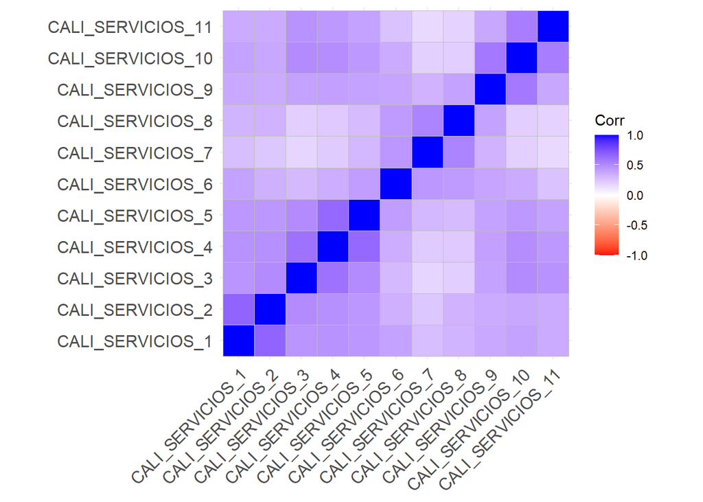

```r
library(ggcorrplot)
ggcorrplot(corMatrix,colors = c("#ff0000", "white", "#0000ff"))
```

Prueba KMO

```r
library(psych)
KMO(corMatrix)
```

```
## Kaiser-Meyer-Olkin factor adequacy
## Call: KMO(r = corMatrix)
## Overall MSA =  0.88
## MSA for each item =
##  CALI_SERVICIOS_1  CALI_SERVICIOS_2  CALI_SERVICIOS_3  CALI_SERVICIOS_4
##              0.87              0.86              0.92              0.88
##  CALI_SERVICIOS_5  CALI_SERVICIOS_6  CALI_SERVICIOS_7  CALI_SERVICIOS_8
##              0.90              0.91              0.82              0.82
##  CALI_SERVICIOS_9 CALI_SERVICIOS_10 CALI_SERVICIOS_11
##              0.89              0.86              0.91
```

```r
cortest.bartlett(corMatrix,n=nrow(subdata))$p.value>0.05
```

```
## [1] FALSE
```

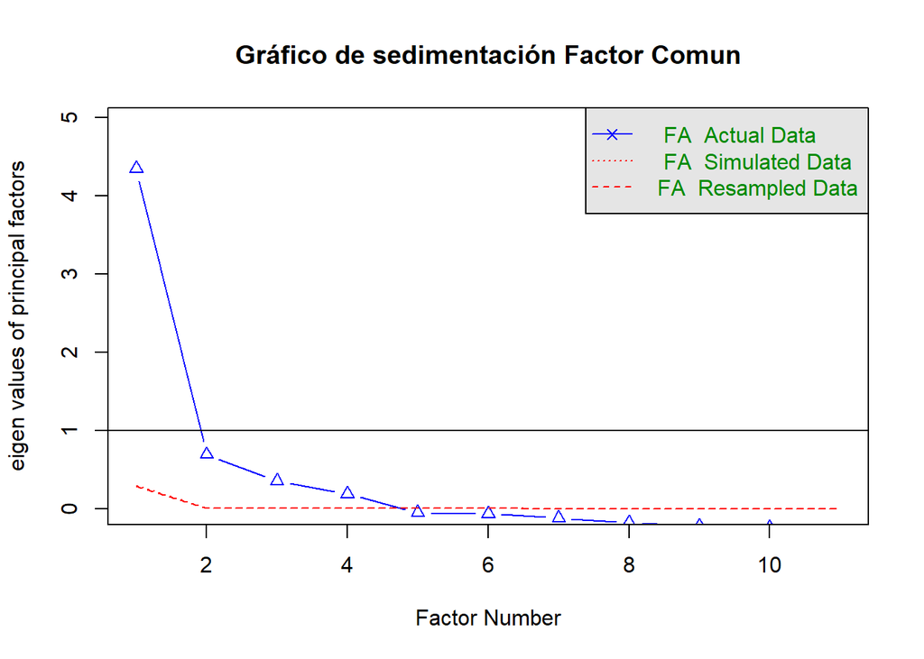

```
## Parallel analysis suggests that the number of factors =  4  and the number of components =  NA
```

```r
#Factor Común
fa.parallel(subdata, fm="pa", fa="fa", main = "Gráfico de sedimentación Factor Comun")
```

```r
#Factor Común
eigen<-eigen(cor(subdata, use="complete"))
eigen$values
```

```
##  [1] 4.9239394 1.4018385 0.9166692 0.7176617 0.5840172 0.5692293 0.4587326
##  [8] 0.4554159 0.3398068 0.3228182 0.3098712
```

```r
#Factor Común
library(GPArotation)
factorial <- fa(subdata,nfactors = 2,rotate = "varimax",fm="minres")
```

```r
print(factorial$loadings)
```

```
##
## Loadings:
##                   MR1   MR2
## CALI_SERVICIOS_1  0.584 0.334
## CALI_SERVICIOS_2  0.599 0.295
## CALI_SERVICIOS_3  0.741 0.118
## CALI_SERVICIOS_4  0.748 0.176
## CALI_SERVICIOS_5  0.641 0.298
## CALI_SERVICIOS_6  0.341 0.555
## CALI_SERVICIOS_7  0.113 0.715
## CALI_SERVICIOS_8  0.157 0.712
## CALI_SERVICIOS_9  0.505 0.392
## CALI_SERVICIOS_10 0.677 0.184
## CALI_SERVICIOS_11 0.614 0.108
##
##                  MR1   MR2
## SS loadings    3.464 1.859
## Proportion Var 0.315 0.169
## Cumulative Var 0.315 0.484
```

```r
print(factorial$loadings,cutoff = 0.5)
```

```
##
## Loadings:
##                   MR1   MR2
## CALI_SERVICIOS_1  0.584
## CALI_SERVICIOS_2  0.599
## CALI_SERVICIOS_3  0.741
## CALI_SERVICIOS_4  0.748
## CALI_SERVICIOS_5  0.641
## CALI_SERVICIOS_6        0.555
## CALI_SERVICIOS_7        0.715
## CALI_SERVICIOS_8        0.712
## CALI_SERVICIOS_9  0.505
## CALI_SERVICIOS_10 0.677
## CALI_SERVICIOS_11 0.614
##
##                  MR1   MR2
## SS loadings    3.464 1.859
## Proportion Var 0.315 0.169
## Cumulative Var 0.315 0.484
```

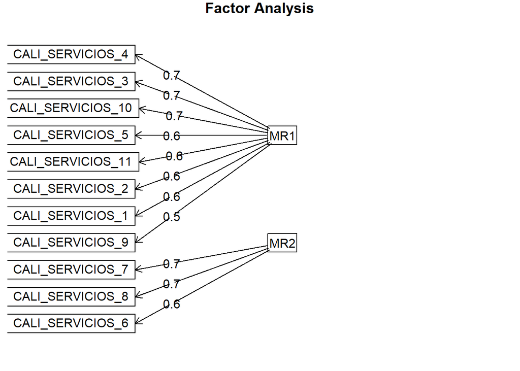

```r
fa.diagram(factorial)
```

```r
library("devtools")
library("factoextra")
```

- ¿Qué variables aportaron mas a los factores?

```r
sort(factorial$communality)
```

```
## CALI_SERVICIOS_11  CALI_SERVICIOS_9  CALI_SERVICIOS_6  CALI_SERVICIOS_2
##         0.3892678         0.4091955         0.4247956         0.4453151
##  CALI_SERVICIOS_1 CALI_SERVICIOS_10  CALI_SERVICIOS_5  CALI_SERVICIOS_7
##         0.4532078         0.4922657         0.4999366         0.5244548
##  CALI_SERVICIOS_8  CALI_SERVICIOS_3  CALI_SERVICIOS_4
##         0.5312386         0.5629013         0.5908609
```

- ¿Qué variables contribuyen a mas de un factor?

```r
sort(factorial$complexity)
```

```
##  CALI_SERVICIOS_7  CALI_SERVICIOS_3 CALI_SERVICIOS_11  CALI_SERVICIOS_8
##          1.049493          1.050990          1.062174          1.097099
##  CALI_SERVICIOS_4 CALI_SERVICIOS_10  CALI_SERVICIOS_5  CALI_SERVICIOS_2
##          1.109742          1.147342          1.413500          1.457971
##  CALI_SERVICIOS_1  CALI_SERVICIOS_6  CALI_SERVICIOS_9
##          1.591368          1.660459          1.884803
```

- ¿Qué variables tiene un componente “único” más grande?

```r
sort(factorial$uniquenesses)
```

```
##  CALI_SERVICIOS_4  CALI_SERVICIOS_3  CALI_SERVICIOS_8  CALI_SERVICIOS_7
##         0.4091391         0.4370987         0.4687614         0.4755452
##  CALI_SERVICIOS_5 CALI_SERVICIOS_10  CALI_SERVICIOS_1  CALI_SERVICIOS_2
##         0.5000634         0.5077343         0.5467922         0.5546849
##  CALI_SERVICIOS_6  CALI_SERVICIOS_9 CALI_SERVICIOS_11
##         0.5752044         0.5908045         0.6107322
```

```r
factorial_casos<-as.data.frame(factorial$scores)
head(factorial_casos)
```

```
##           MR1         MR2
## 1  0.04575999 -0.55633971
## 2  1.66295304  0.28545823
## 3  1.91759610  0.18182852
## 4 -0.83257387  0.04529709
## 5  1.91759610  0.18182852
## 6 -0.69028896 -0.92219534
```

```r
summary(factorial_casos)
```

```
##       MR1             MR2
##  Min.   :-2.20   Min.   :-2.84
##  1st Qu.:-0.62   1st Qu.:-0.59
##  Median :-0.05   Median : 0.11
##  Mean   : 0.00   Mean   : 0.00
##  3rd Qu.: 0.54   3rd Qu.: 0.68
##  Max.   : 3.36   Max.   : 1.87
##  NA's   :38036   NA's   :38036
```

```r
subdata$factor1<- factorial_casos$MR1
subdata$factor2<- factorial_casos$MR2
```

```r
library(BBmisc)
subdata$comp1_normalizado = normalize(subdata$factor1,
                                        method = "range",
                                        margin=2, # by column
                                        range = c(0, 100))
subdata$comp2_normalizado = normalize(subdata$factor2,
                                        method = "range",
                                        margin=2, # by column
                                        range = c(0, 100))

summary(subdata$comp2_normalizado)
```

```
##    Min. 1st Qu.  Median    Mean 3rd Qu.    Max.    NA's
##    0.00   47.76   62.68   60.26   74.79  100.00   38036
```

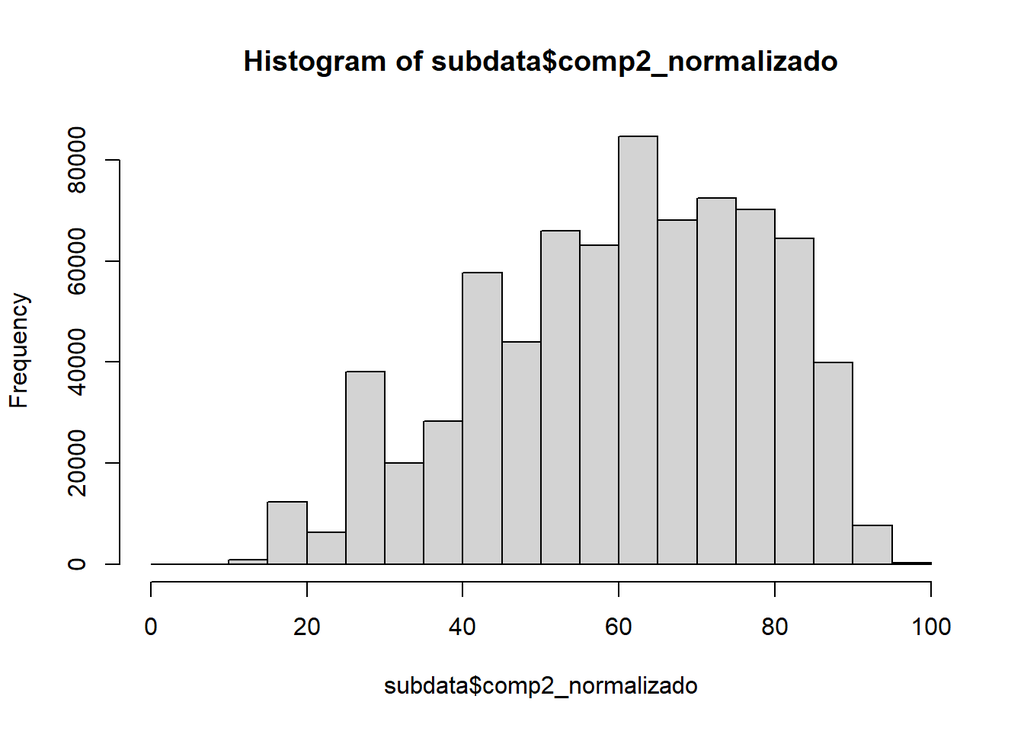

```r
hist(subdata$comp2_normalizado)
```

#2.

```r
library(polycor)
corMatrix2=polycor::hetcor(subdata2)$correlations
corMatrix2
```

```
##               CALI_AREAS_1 CALI_AREAS_2 CALI_AREAS_3 CALI_AREAS_4 CALI_AREAS_5
## CALI_AREAS_1     1.0000000    0.5386911    0.5804954    0.5904594    0.6061752
## CALI_AREAS_2     0.5386911    1.0000000    0.5567338    0.5040235    0.4901868
## CALI_AREAS_3     0.5804954    0.5567338    1.0000000    0.6421096    0.5375438
## CALI_AREAS_4     0.5904594    0.5040235    0.6421096    1.0000000    0.5639144
## CALI_AREAS_5     0.6061752    0.4901868    0.5375438    0.5639144    1.0000000
## CALI_AREAS_6     0.4253023    0.4934703    0.4940384    0.4921763    0.5275493
## CALI_AREAS_7     0.4054113    0.4164594    0.4509027    0.4719087    0.4393055
## CALI_AREAS_8     0.3722045    0.3835611    0.4328519    0.4517290    0.3685756
## CALI_AREAS_9     0.4507254    0.4127802    0.4474614    0.4705261    0.4312285
## CALI_AREAS_10    0.4899319    0.4747409    0.5522917    0.5208980    0.4751119
##               CALI_AREAS_6 CALI_AREAS_7 CALI_AREAS_8 CALI_AREAS_9 CALI_AREAS_10
## CALI_AREAS_1     0.4253023    0.4054113    0.3722045    0.4507254     0.4899319
## CALI_AREAS_2     0.4934703    0.4164594    0.3835611    0.4127802     0.4747409
## CALI_AREAS_3     0.4940384    0.4509027    0.4328519    0.4474614     0.5522917
## CALI_AREAS_4     0.4921763    0.4719087    0.4517290    0.4705261     0.5208980
## CALI_AREAS_5     0.5275493    0.4393055    0.3685756    0.4312285     0.4751119
## CALI_AREAS_6     1.0000000    0.5572734    0.4990249    0.4392062     0.4890753
## CALI_AREAS_7     0.5572734    1.0000000    0.6108450    0.4106032     0.4762455
## CALI_AREAS_8     0.4990249    0.6108450    1.0000000    0.4192634     0.4995944
## CALI_AREAS_9     0.4392062    0.4106032    0.4192634    1.0000000     0.4868554
## CALI_AREAS_10    0.4890753    0.4762455    0.4995944    0.4868554     1.0000000
```

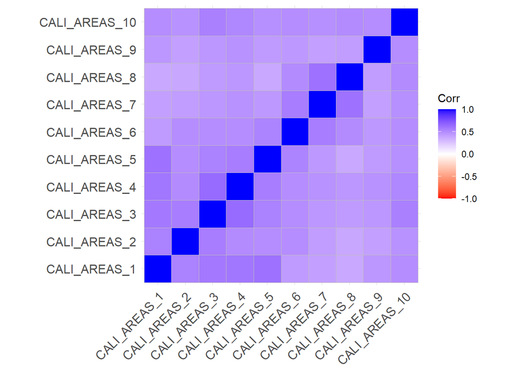

```r
library(ggcorrplot)
ggcorrplot(corMatrix2,colors = c("#ff0000", "white", "#0000ff"))
```

Prueba KMO

```r
library(psych)
KMO(corMatrix2)
```

```
## Kaiser-Meyer-Olkin factor adequacy
## Call: KMO(r = corMatrix2)
## Overall MSA =  0.93
## MSA for each item =
##  CALI_AREAS_1  CALI_AREAS_2  CALI_AREAS_3  CALI_AREAS_4  CALI_AREAS_5
##          0.92          0.95          0.93          0.94          0.93
##  CALI_AREAS_6  CALI_AREAS_7  CALI_AREAS_8  CALI_AREAS_9 CALI_AREAS_10
##          0.93          0.91          0.90          0.96          0.95
```

```r
cortest.bartlett(corMatrix,n=nrow(subdata2))$p.value>0.05
```

```
## [1] FALSE
```

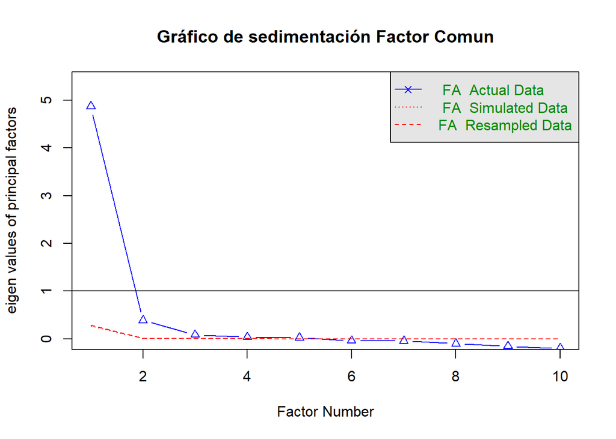

```
## Parallel analysis suggests that the number of factors =  5  and the number of components =  NA
```

```r
#Factor Común
fa.parallel(subdata2, fm="pa", fa="fa", main = "Gráfico de sedimentación Factor Comun")
```

```r
#Factor Común
eigen<-eigen(cor(subdata2, use="complete"))
eigen$values
```

```
##  [1] 5.3814049 0.9192185 0.6278028 0.5543386 0.5354738 0.4740778 0.4508437
##  [8] 0.3715404 0.3444410 0.3408586
```

```r
#Factor Común
library(GPArotation)
factorial2 <- fa(subdata2,nfactors = 2,rotate = "varimax",fm="minres")
```

```r
print(factorial2$loadings)
```

```
##
## Loadings:
##               MR1   MR2
## CALI_AREAS_1  0.749 0.227
## CALI_AREAS_2  0.608 0.326
## CALI_AREAS_3  0.697 0.342
## CALI_AREAS_4  0.681 0.363
## CALI_AREAS_5  0.670 0.304
## CALI_AREAS_6  0.455 0.554
## CALI_AREAS_7  0.308 0.716
## CALI_AREAS_8  0.256 0.732
## CALI_AREAS_9  0.474 0.401
## CALI_AREAS_10 0.524 0.477
##
##                  MR1   MR2
## SS loadings    3.197 2.242
## Proportion Var 0.320 0.224
## Cumulative Var 0.320 0.544
```

```r
print(factorial2$loadings,cutoff = 0.5)
```

```
##
## Loadings:
##               MR1   MR2
## CALI_AREAS_1  0.749
## CALI_AREAS_2  0.608
## CALI_AREAS_3  0.697
## CALI_AREAS_4  0.681
## CALI_AREAS_5  0.670
## CALI_AREAS_6        0.554
## CALI_AREAS_7        0.716
## CALI_AREAS_8        0.732
## CALI_AREAS_9
## CALI_AREAS_10 0.524
##
##                  MR1   MR2
## SS loadings    3.197 2.242
## Proportion Var 0.320 0.224
## Cumulative Var 0.320 0.544
```

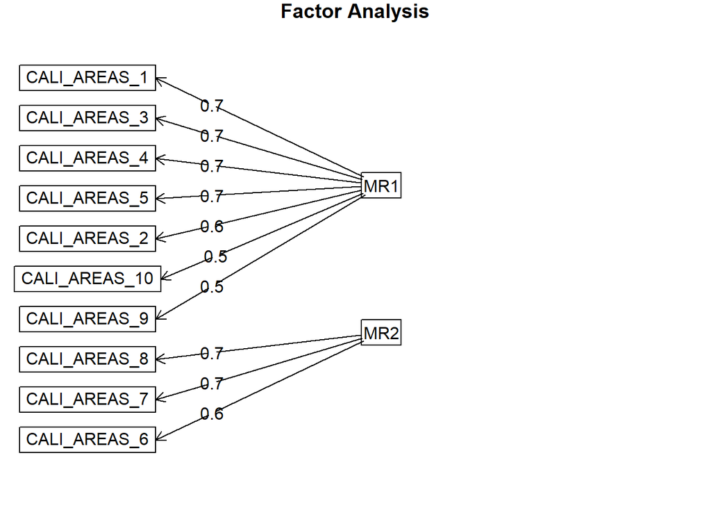

```r
fa.diagram(factorial2)
```

- ¿Qué variables aportaron mas a los factores?

```r
sort(factorial2$communality)
```

```
##  CALI_AREAS_9  CALI_AREAS_2 CALI_AREAS_10  CALI_AREAS_6  CALI_AREAS_5
##     0.3858615     0.4764924     0.5023590     0.5137600     0.5408185
##  CALI_AREAS_4  CALI_AREAS_8  CALI_AREAS_3  CALI_AREAS_7  CALI_AREAS_1
##     0.5959574     0.6009583     0.6033089     0.6071729     0.6123398
```

- ¿Qué variables contribuyen a mas de un factor?

```r
sort(factorial2$complexity)
```

```
##  CALI_AREAS_1  CALI_AREAS_8  CALI_AREAS_7  CALI_AREAS_5  CALI_AREAS_3
##      1.181596      1.242039      1.357337      1.394781      1.455996
##  CALI_AREAS_4  CALI_AREAS_2  CALI_AREAS_6  CALI_AREAS_9 CALI_AREAS_10
##      1.524908      1.531282      1.927336      1.946202      1.982411
```

- ¿Qué variables tiene un componente “único” más grande?

```r
sort(factorial2$uniquenesses)
```

```
##  CALI_AREAS_1  CALI_AREAS_7  CALI_AREAS_3  CALI_AREAS_8  CALI_AREAS_4
##     0.3876602     0.3928271     0.3966911     0.3990417     0.4040426
##  CALI_AREAS_5  CALI_AREAS_6 CALI_AREAS_10  CALI_AREAS_2  CALI_AREAS_9
##     0.4591815     0.4862400     0.4976410     0.5235076     0.6141385
```

```r
factorial2_casos<-as.data.frame(factorial2$scores)
head(factorial2_casos)
```

```
##          MR1        MR2
## 1 -1.2021349 -0.9435311
## 2  0.9998752  1.1431240
## 3  2.3344806  0.7911924
## 4 -0.7403391  0.4834795
## 5  2.3344806  0.7911924
## 6 -0.5212136 -0.8284277
```

```r
summary(factorial2_casos)
```

```
##       MR1             MR2
##  Min.   :-2.63   Min.   :-2.56
##  1st Qu.:-0.55   1st Qu.:-0.62
##  Median :-0.02   Median :-0.16
##  Mean   : 0.00   Mean   : 0.00
##  3rd Qu.: 0.53   3rd Qu.: 0.51
##  Max.   : 3.96   Max.   : 2.89
##  NA's   :38036   NA's   :38036
```

```r
subdata2$factor1<- factorial2_casos$MR1
subdata2$factor2<- factorial2_casos$MR2
```

```r
library(BBmisc)
subdata2$comp1_normalizado = normalize(subdata2$factor1,
                                        method = "range",
                                        margin=2, # by column
                                        range = c(0, 100))
subdata2$comp2_normalizado = normalize(subdata2$factor2,
                                        method = "range",
                                        margin=2, # by column
                                        range = c(0, 100))
summary(subdata2$comp2_normalizado)
```

```
##    Min. 1st Qu.  Median    Mean 3rd Qu.    Max.    NA's
##    0.00   35.65   44.08   47.00   56.39  100.00   38036
```

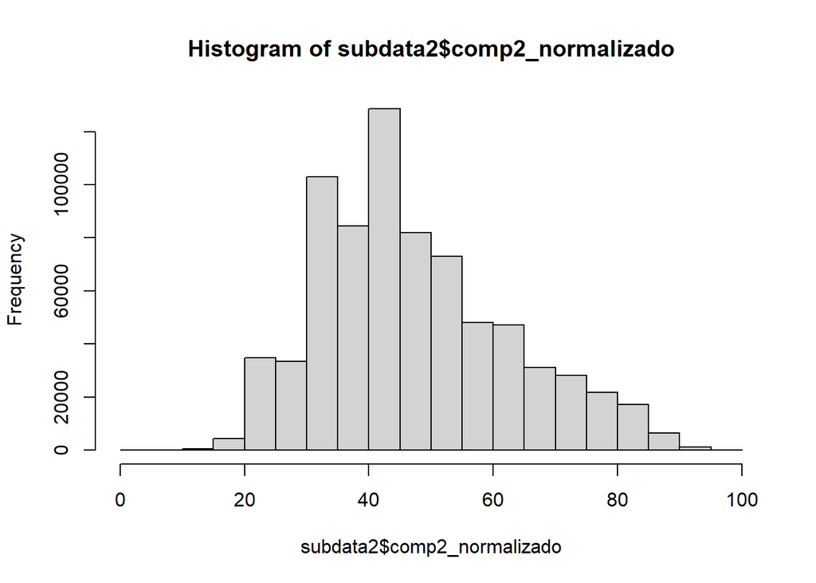

```r
hist(subdata2$comp2_normalizado)
```

Modelo

Modelo con factores de servicios

```r
mod1<-lm(data1$PERSPECTIVA~ subdata$comp1_normalizado+ subdata$comp2_normalizado+data1$CURSO+data1$INVES+data1$ORG_ESTU+data1$ACT_CULTURAL+data1$PRAC_DEPO+data1$USO_BIBLIOTRADI+data1$USO_BIBLIOVIRTUAL+data1$BECA_UNIV)
summary(mod1)
```

```
##
## Call:
## lm(formula = data1$PERSPECTIVA ~ subdata$comp1_normalizado +
##     subdata$comp2_normalizado + data1$CURSO + data1$INVES + data1$ORG_ESTU +
##     data1$ACT_CULTURAL + data1$PRAC_DEPO + data1$USO_BIBLIOTRADI +
##     data1$USO_BIBLIOVIRTUAL + data1$BECA_UNIV)
##
## Residuals:
##     Min      1Q  Median      3Q     Max
## -2.5579 -0.4104 -0.0081  0.3822  6.2585
##
## Coefficients:
##                             Estimate Std. Error t value Pr(>|t|)
## (Intercept)                8.712e-01  9.171e-03  94.989  < 2e-16 ***
## subdata$comp1_normalizado  2.060e-02  5.733e-05 359.219  < 2e-16 ***
## subdata$comp2_normalizado  1.007e-03  4.624e-05  21.783  < 2e-16 ***
## data1$CURSO                4.863e-02  2.372e-03  20.506  < 2e-16 ***
## data1$INVES                1.059e-01  2.087e-03  50.734  < 2e-16 ***
## data1$ORG_ESTU            -4.615e-02  2.962e-03 -15.580  < 2e-16 ***
## data1$ACT_CULTURAL         2.548e-02  3.131e-03   8.138 4.03e-16 ***
## data1$PRAC_DEPO           -1.901e-02  1.977e-03  -9.612  < 2e-16 ***
## data1$USO_BIBLIOTRADI     -5.225e-02  1.864e-03 -28.028  < 2e-16 ***
## data1$USO_BIBLIOVIRTUAL    8.720e-02  1.746e-03  49.957  < 2e-16 ***
## data1$BECA_UNIV            6.698e-02  2.562e-03  26.147  < 2e-16 ***
## ---
## Signif. codes:  0 '***' 0.001 '**' 0.01 '*' 0.05 '.' 0.1 ' ' 1
##
## Residual standard error: 0.626 on 613867 degrees of freedom
##   (169092 observations deleted due to missingness)
## Multiple R-squared:   0.25,  Adjusted R-squared:   0.25
## F-statistic: 2.046e+04 on 10 and 613867 DF,  p-value: < 2.2e-16
```

```r
mod1.2<-lm(data1$CALIDAD_UNIV~ subdata$comp1_normalizado+ subdata$comp2_normalizado+data1$CURSO+data1$INVES+data1$ORG_ESTU+data1$ACT_CULTURAL+data1$PRAC_DEPO+data1$USO_BIBLIOTRADI+data1$USO_BIBLIOVIRTUAL+data1$BECA_UNIV)
summary(mod1.2)
```

```
##
## Call:
## lm(formula = data1$CALIDAD_UNIV ~ subdata$comp1_normalizado +
##     subdata$comp2_normalizado + data1$CURSO + data1$INVES + data1$ORG_ESTU +
##     data1$ACT_CULTURAL + data1$PRAC_DEPO + data1$USO_BIBLIOTRADI +
##     data1$USO_BIBLIOVIRTUAL + data1$BECA_UNIV)
##
## Residuals:
##     Min      1Q  Median      3Q     Max
## -2.7542 -0.3929 -0.0035  0.3811  7.4780
##
## Coefficients:
##                             Estimate Std. Error t value Pr(>|t|)
## (Intercept)                9.587e-01  8.805e-03 108.871  < 2e-16 ***
## subdata$comp1_normalizado  2.031e-02  5.505e-05 368.877  < 2e-16 ***
## subdata$comp2_normalizado  7.110e-04  4.439e-05  16.016  < 2e-16 ***
## data1$CURSO                7.252e-02  2.277e-03  31.848  < 2e-16 ***
## data1$INVES                1.234e-01  2.004e-03  61.605  < 2e-16 ***
## data1$ORG_ESTU            -4.896e-02  2.844e-03 -17.217  < 2e-16 ***
## data1$ACT_CULTURAL         1.904e-02  3.006e-03   6.333 2.41e-10 ***
## data1$PRAC_DEPO           -3.447e-02  1.899e-03 -18.156  < 2e-16 ***
## data1$USO_BIBLIOTRADI     -4.810e-02  1.790e-03 -26.872  < 2e-16 ***
## data1$USO_BIBLIOVIRTUAL    8.166e-02  1.676e-03  48.726  < 2e-16 ***
## data1$BECA_UNIV            5.060e-02  2.460e-03  20.574  < 2e-16 ***
## ---
## Signif. codes:  0 '***' 0.001 '**' 0.01 '*' 0.05 '.' 0.1 ' ' 1
##
## Residual standard error: 0.601 on 613867 degrees of freedom
##   (169092 observations deleted due to missingness)
## Multiple R-squared:  0.2688, Adjusted R-squared:  0.2688
## F-statistic: 2.256e+04 on 10 and 613867 DF,  p-value: < 2.2e-16
```

Comparando encontramos que de igual forma respecto a calidad univ, la predictibilidad solo aumenta en un 1.88.

Modelo con factores de calidad de areas

```r
mod2<-lm(data1$CALIDAD_UNIV~ subdata2$comp1_normalizado+ subdata2$comp2_normalizado+data1$CURSO+data1$INVES+data1$ORG_ESTU+data1$ACT_CULTURAL+data1$PRAC_DEPO+data1$USO_BIBLIOTRADI+data1$USO_BIBLIOVIRTUAL+data1$BECA_UNIV)
summary(mod2)
```

```
##
## Call:
## lm(formula = data1$CALIDAD_UNIV ~ subdata2$comp1_normalizado +
##     subdata2$comp2_normalizado + data1$CURSO + data1$INVES +
##     data1$ORG_ESTU + data1$ACT_CULTURAL + data1$PRAC_DEPO + data1$USO_BIBLIOTRADI +
##     data1$USO_BIBLIOVIRTUAL + data1$BECA_UNIV)
##
## Residuals:
##     Min      1Q  Median      3Q     Max
## -2.8161 -0.3703 -0.0095  0.3847  7.5169
##
## Coefficients:
##                              Estimate Std. Error t value Pr(>|t|)
## (Intercept)                 4.158e-01  8.490e-03  48.978   <2e-16 ***
## subdata2$comp1_normalizado  2.439e-02  6.451e-05 378.037   <2e-16 ***
## subdata2$comp2_normalizado  6.357e-03  5.254e-05 121.011   <2e-16 ***
## data1$CURSO                 7.023e-02  2.224e-03  31.583   <2e-16 ***
## data1$INVES                 1.161e-01  1.956e-03  59.370   <2e-16 ***
## data1$ORG_ESTU             -3.223e-02  2.781e-03 -11.588   <2e-16 ***
## data1$ACT_CULTURAL          4.828e-02  2.937e-03  16.437   <2e-16 ***
## data1$PRAC_DEPO            -1.743e-02  1.855e-03  -9.395   <2e-16 ***
## data1$USO_BIBLIOTRADI      -3.316e-02  1.743e-03 -19.026   <2e-16 ***
## data1$USO_BIBLIOVIRTUAL     8.401e-02  1.636e-03  51.359   <2e-16 ***
## data1$BECA_UNIV             4.303e-02  2.405e-03  17.893   <2e-16 ***
## ---
## Signif. codes:  0 '***' 0.001 '**' 0.01 '*' 0.05 '.' 0.1 ' ' 1
##
## Residual standard error: 0.5877 on 613867 degrees of freedom
##   (169092 observations deleted due to missingness)
## Multiple R-squared:  0.3007, Adjusted R-squared:  0.3007
## F-statistic: 2.64e+04 on 10 and 613867 DF,  p-value: < 2.2e-16
```

El modelo tiene un pvalor menor a 0,05 por tanto es válido. El R cuadrado ajustado es de 0.30 lo cual significa que el modelo explica el 30% de la variable dependiente . Vemos que el pvalor de cada variables es menor a 0.05 por tanto todas las variables aportan a la explicación del modelo. Podemos verificar que el modelo explica en forma reducida a la variable dependiente, lo cual podría ser resultado de las distancias (varianzas) entre las variables adicionales y el modelo de factor común: Curso,organizacion estudiantil, investigacion,actividades culturales,practica deportiva,uso biblioteca , biblioteca virtual, beca universidad.

Conclusión: Observamos que el modelo 2 predice mejor el puntaje que se puede obtener de los alumnos, por lo que es mas completo. Encontramos que comparativamente se puede hacer un mejor seguimiento de lo que se puede esperar en calidad segun el puntaje que se otorga por los factores de las areas, en comparacion de lo que se podria lograr entender respecto a perspectiva por los factores de servicios. A causa de lo mencionado concluimos que la aprobación respecto a la aprobación en áreas universitarias contribuye más en la calidad formativa y desarrollo de las universidades, a comparación de la los servicios universitarios.